# Machine Learning

David C. King

# https://bradleyboehmke.github.io/HOML/intro.html

## Ames Housing Data

Property sales information as described in De Cock (2011). - problem type: supervised regression - response variable: Sale_Price (i.e., $195,000, $215,000) - features: 80 - observations: 2,930 - objective: use property attributes to predict the sale price of a home - access: provided by the AmesHousing package (Kuhn 2017a)

more details: See ?AmesHousing::ames_raw

```r
# access data
ames <- AmesHousing::make_ames()

# initial dimension
dim(ames)
```

```
## [1] 2930   81
```

```r
## [1] 2930   81

# response variable
head(ames$Sale_Price)
```

```
## [1] 215000 105000 172000 244000 189900 195500
```

```r
## [1] 215000 105000 172000 244000 189900 195500
```

### Note:

You can see the entire data cleaning process to transform the raw Ames housing data (AmesHousing::ames_raw) to the final clean data (AmesHousing::make_ames) that we will use in machine learning algorithms throughout this book by typing AmesHousing::make_ames into the R console.

## Datasets

Employee attrition information originally provided by IBM Watson Analytics Lab. - problem type: supervised binomial classification - response variable: Attrition (i.e., “Yes”, “No”) - features: 30 - observations: 1,470 - objective: use employee attributes to predict if they will attrit (leave the company) - access: provided by the rsample package (Kuhn and Wickham 2019)

more details: See ?rsample::attrition

```r
# These data are now in the modeldata package.
# access data
#attrition <- rsample::attrition
library(modeldata)
data(attrition)

# initial dimension
dim(attrition)
```

```
## [1] 1470   31
```

```r
## [1] 1470   31

# response variable
head(attrition$Attrition)
```

```
## [1] Yes No  Yes No  No  No
## Levels: No Yes
```

```r
## [1] Yes No  Yes No  No  No
## Levels: No Yes
```

Image information for handwritten numbers originally presented to AT&T Bell Lab’s to help build automatic mail-sorting machines for the USPS. Has been used since early 1990s to compare machine learning performance on pattern recognition (i.e., LeCun et al. (1990); LeCun et al. (1998); Cireşan, Meier, and Schmidhuber (2012)). Problem type: supervised multinomial classification response variable: V785 (i.e., numbers to predict: 0, 1, …, 9) features: 784 observations: 60,000 (train) / 10,000 (test) objective: use attributes about the “darkness” of each of the 784 pixels in images of handwritten numbers to predict if the number is 0, 1, …, or 9. access: provided by the dslabs package (Irizarry 2018) more details: See ?dslabs::read_mnist() and online MNIST documentation

```r
#access data
mnist <- dslabs::read_mnist()
names(mnist)
```

```
## [1] "train" "test"
```

```r
## [1] "train" "test"

# initial feature dimensions
dim(mnist$train$images)
```

```
## [1] 60000   784
```

```r
## [1] 60000   784

# response variable
head(mnist$train$labels)
```

```
## [1] 5 0 4 1 9 2
```

```r
## [1] 5 0 4 1 9 2
```

```r
# URL to download/read in the data
url <- "https://koalaverse.github.io/homlr/data/my_basket.csv"

# Access data
my_basket <- readr::read_csv(url)
# Print dimensions
dim(my_basket)
```

```
## [1] 2000   42
```

```r
## [1] 2000   42

# Peek at response variable
my_basket
```

```
## # A tibble: 2,000 × 42
##    `7up` lasagna pepsi   yop red.wine cheese   bbq bulmers mayonnaise horlics
##    <dbl>   <dbl> <dbl> <dbl>    <dbl>  <dbl> <dbl>   <dbl>      <dbl>   <dbl>
##  1     0       0     0     0        0      0     0       0          0       0
##  2     0       0     0     0        0      0     0       0          0       0
##  3     0       0     0     0        0      0     0       0          0       0
##  4     0       0     0     2        1      0     0       0          0       0
##  5     0       0     0     0        0      0     0       2          0       0
##  6     0       0     0     0        0      0     0       0          0       0
##  7     1       1     0     0        0      0     1       0          0       0
##  8     0       0     0     0        0      0     0       0          0       0
##  9     0       1     0     0        0      0     0       0          0       0
## 10     0       0     0     0        0      0     0       0          0       2
## # … with 1,990 more rows, and 32 more variables: chicken.tikka <dbl>,
## #   milk <dbl>, mars <dbl>, coke <dbl>, lottery <dbl>, bread <dbl>,
## #   pizza <dbl>, sunny.delight <dbl>, ham <dbl>, lettuce <dbl>,
## #   kronenbourg <dbl>, leeks <dbl>, fanta <dbl>, tea <dbl>, whiskey <dbl>,
## #   peas <dbl>, newspaper <dbl>, muesli <dbl>, white.wine <dbl>, carrots <dbl>,
## #   spinach <dbl>, pate <dbl>, instant.coffee <dbl>, twix <dbl>,
## #   potatoes <dbl>, fosters <dbl>, soup <dbl>, toad.in.hole <dbl>, …
```

```r
## # A tibble: 2,000 x 42
##    `7up` lasagna pepsi   yop red.wine cheese   bbq bulmers mayonnaise
##    <dbl>   <dbl> <dbl> <dbl>    <dbl>  <dbl> <dbl>   <dbl>      <dbl>
##  1     0       0     0     0        0      0     0       0          0
##  2     0       0     0     0        0      0     0       0          0
##  3     0       0     0     0        0      0     0       0          0
##  4     0       0     0     2        1      0     0       0          0
##  5     0       0     0     0        0      0     0       2          0
##  6     0       0     0     0        0      0     0       0          0
##  7     1       1     0     0        0      0     1       0          0
##  8     0       0     0     0        0      0     0       0          0
##  9     0       1     0     0        0      0     0       0          0
## 10     0       0     0     0        0      0     0       0          0
## # … with 1,990 more rows, and 33 more variables: horlics <dbl>,
## #   chicken.tikka <dbl>, milk <dbl>, mars <dbl>, coke <dbl>,
## #   lottery <dbl>, bread <dbl>, pizza <dbl>, sunny.delight <dbl>,
## #   ham <dbl>, lettuce <dbl>, kronenbourg <dbl>, leeks <dbl>, fanta <dbl>,
## #   tea <dbl>, whiskey <dbl>, peas <dbl>, newspaper <dbl>, muesli <dbl>,
## #   white.wine <dbl>, carrots <dbl>, spinach <dbl>, pate <dbl>,
## #   instant.coffee <dbl>, twix <dbl>, potatoes <dbl>, fosters <dbl>,
## #   soup <dbl>, toad.in.hole <dbl>, coco.pops <dbl>, kitkat <dbl>,
## #   broccoli <dbl>, cigarettes <dbl>
```

### h2o installation and update

## Modeling Process

```r
library(h2o)

# h2o set-up
h2o.no_progress()  # turn off h2o progress bars

h2o.init()         # launch h2o.
```

```
##  Connection successful!
##
## R is connected to the H2O cluster:
##     H2O cluster uptime:         4 days 21 hours
##     H2O cluster timezone:       America/Denver
##     H2O data parsing timezone:  UTC
##     H2O cluster version:        3.38.0.1
##     H2O cluster version age:    7 days, 21 hours and 29 minutes
##     H2O cluster name:           H2O_started_from_R_david_krr608
##     H2O cluster total nodes:    1
##     H2O cluster total memory:   2.00 GB
##     H2O cluster total cores:    8
##     H2O cluster allowed cores:  8
##     H2O cluster healthy:        TRUE
##     H2O Connection ip:          localhost
##     H2O Connection port:        54321
##     H2O Connection proxy:       NA
##     H2O Internal Security:      FALSE
##     R Version:                  R version 4.2.1 (2022-06-23)
```

```r
# Ames housing data
ames <- AmesHousing::make_ames()
ames.h2o <- as.h2o(ames)

# Job attrition data is now in modeldata, so just do:
# data(attrition)
#churn <- rsample::attrition %>%
churn <- attrition %>%
  mutate_if(is.ordered, .funs = factor, ordered = FALSE)
churn.h2o <- as.h2o(churn)
```

## Data splitting

A major goal of the machine learning process is to find an algorithm  
f ( X ) that most accurately predicts future values ( ^ Y ) based on a set of features ( X ). In other words, we want an algorithm that not only fits well to our past data, but more importantly, one that predicts a future outcome accurately. This is called the generalizability of our algorithm. How we “spend” our data will help us understand how well our algorithm generalizes to unseen data.

To provide an accurate understanding of the generalizability of our final optimal model, we can split our data into training and test data sets:

Training set: these data are used to develop feature sets, train our algorithms, tune hyperparameters, compare models, and all of the other activities required to choose a final model (e.g., the model we want to put into production). Test set: having chosen a final model, these data are used to estimate an unbiased assessment of the model’s performance, which we refer to as the generalization error. It is critical that the test set not be used prior to selecting your final model. Assessing results on the test set prior to final model selection biases the model selection process since the testing data will have become part of the model development process.

Given a fixed amount of data, typical recommendations for splitting your data into training-test splits include 60% (training)–40% (testing), 70%–30%, or 80%–20%. Generally speaking, these are appropriate guidelines to follow; however, it is good to keep the following points in mind:

Spending too much in training (e.g., >80%) won’t allow us to get a good assessment of predictive performance. We may find a model that fits the training data very well, but is not generalizable (overfitting). Sometimes too much spent in testing ( >40%) won’t allow us to get a good assessment of model parameters. Other factors should also influence the allocation proportions. For example, very large training sets (e.g.,  
n>100K) often result in only marginal gains compared to smaller sample sizes. Consequently, you may use a smaller training sample to increase computation speed (e.g., models built on larger training sets often take longer to score new data sets in production). In contrast, as p≥n (where p represents the number of features), larger samples sizes are often required to identify consistent signals in the features.

The two most common ways of splitting data include simple random sampling and stratified sampling.

### Simple Random Sampling

The simplest way to split the data into training and test sets is to take a simple random sample. This does not control for any data attributes, such as the distribution of your response variable ( Y ). There are multiple ways to split our data in R. Here we show four options to produce a 70–30 split in the Ames housing data:

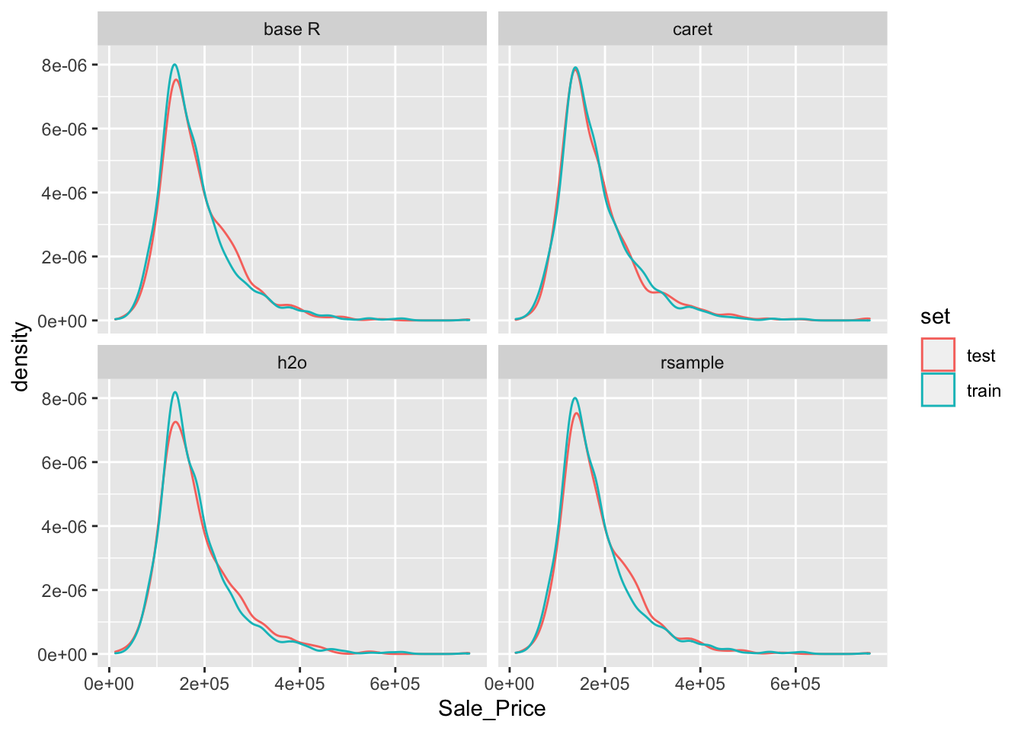

```r
# Using base R
set.seed(123)  # for reproducibility
index_1 <- sample(1:nrow(ames), round(nrow(ames) * 0.7))
train_1 <- ames[index_1, ]
test_1  <- ames[-index_1, ]

forplotting = data.frame(Sale_Price=train_1$Sale_Price, method="base R", set="train") %>% rbind( data.frame(Sale_Price=test_1$Sale_Price, method="base R", set="test"))

# Using caret package
set.seed(123)  # for reproducibility
index_2 <- createDataPartition(ames$Sale_Price, p = 0.7,
                               list = FALSE)
train_2 <- ames[index_2, ]
test_2  <- ames[-index_2, ]

forplotting = data.frame(Sale_Price=train_2$Sale_Price, method="caret", set="train") %>% rbind( data.frame(Sale_Price=test_2$Sale_Price, method="caret", set="test")) %>% rbind(forplotting)

# Using rsample package
set.seed(123)  # for reproducibility
split_1  <- initial_split(ames, prop = 0.7)
train_3  <- training(split_1)
test_3   <- testing(split_1)

forplotting = data.frame(Sale_Price=train_3$Sale_Price, method="rsample", set="train") %>% rbind( data.frame(Sale_Price=test_3$Sale_Price, method="rsample", set="test")) %>% rbind(forplotting)

# Using h2o package
split_2 <- h2o.splitFrame(ames.h2o, ratios = 0.7,
                          seed = 123)
train_4 <- split_2[[1]]
test_4  <- split_2[[2]]

# accessers don't work for h2o object
# Error in read.table(file = file, header = header, sep = sep, quote = ,  : unused argument (optional = TRUE)

forplotting = data.frame(Sale_Price=as.vector(train_4$Sale_Price), method="h2o", set="train") %>% rbind( data.frame(Sale_Price=as.vector(test_4$Sale_Price), method="h2o", set="test")) %>% rbind(forplotting)

ggplot(forplotting, aes(x=Sale_Price, color=set)) + geom_density() + facet_wrap(~method)
```

### Stratified Sampling

If we want to explicitly control the sampling so that our training and test sets have similar  
Y distributions, we can use stratified sampling. This is more common with classification problems where the response variable may be severely imbalanced (e.g., 90% of observations with response “Yes” and 10% with response “No”). However, we can also apply stratified sampling to regression problems for data sets that have a small sample size and where the response variable deviates strongly from normality (i.e., positively skewed like Sale_Price). With a continuous response variable, stratified sampling will segment  
Y into quantiles and randomly sample from each. Consequently, this will help ensure a balanced representation of the response distribution in both the training and test sets.

The easiest way to perform stratified sampling on a response variable is to use the rsample package, where you specify the response variable to stratify. The following illustrates that in our original employee attrition data we have an imbalanced response (No: 84%, Yes: 16%). By enforcing stratified sampling, both our training and testing sets have approximately equal response distributions.

```r
# original response distribution
table(churn$Attrition) %>% proportions()
```

```
##
##        No       Yes
## 0.8387755 0.1612245
```

```r
##
##        No       Yes
## 0.8387755 0.1612245

# stratified sampling with the rsample package
set.seed(123)
split_strat  <- initial_split(churn, prop = 0.7,
                              strata = "Attrition")
train_strat  <- training(split_strat)
test_strat   <- testing(split_strat)

# consistent response ratio between train & test
table(train_strat$Attrition) %>% proportions()
```

```
##
##        No       Yes
## 0.8394942 0.1605058
```

```r
##
##       No      Yes
## 0.838835 0.161165
table(test_strat$Attrition) %>% proportions()
```

```
##
##        No       Yes
## 0.8371041 0.1628959
```

```r
##
##        No       Yes
## 0.8386364 0.1613636
```

### 2.2.3 Class Imbalances

Imbalanced data can have a significant impact on model predictions and performance (Kuhn and Johnson 2013). Most often this involves classification problems where one class has a very small proportion of observations (e.g., defaults - 5% versus nondefaults - 95%). Several sampling methods have been developed to help remedy class imbalance and most of them can be categorized as either up-sampling or down-sampling.

Down-sampling balances the dataset by reducing the size of the abundant class(es) to match the frequencies in the least prevalent class. This method is used when the quantity of data is sufficient. By keeping all samples in the rare class and randomly selecting an equal number of samples in the abundant class, a balanced new dataset can be retrieved for further modeling. Furthermore, the reduced sample size reduces the computation burden imposed by further steps in the ML process.

On the contrary, up-sampling is used when the quantity of data is insufficient. It tries to balance the dataset by increasing the size of rarer samples. Rather than getting rid of abundant samples, new rare samples are generated by using repetition or bootstrapping (described further in Section 2.4.2).

Note that there is no absolute advantage of one sampling method over another. Application of these two methods depends on the use case it applies to and the data set itself. A combination of over- and under-sampling is often successful and a common approach is known as Synthetic Minority Over-Sampling Technique, or SMOTE (Chawla et al. 2002). This alternative sampling approach, as well as others, can be implemented in R (see the sampling argument in `?caret::trainControl()`). Furthermore, many ML algorithms implemented in R have class weighting schemes to remedy imbalances internally (e.g., most h2o algorithms have a weights_column and balance_classes argument).

```r
# Stratified sampling with the rsample package
set.seed(123)
split <- initial_split(ames, prop = 0.7,
                       strata = "Sale_Price")
ames_train  <- training(split)
ames_test   <- testing(split)
```

Next, we’re going to apply a k-nearest neighbor regressor to our data. To do so, we’ll use caret, which is a meta-engine to simplify the resampling, grid search, and model application processes. The following defines:

- Resampling method: we use 10-fold CV repeated 5 times.
- Grid search: we specify the hyperparameter values to assess (k=2,3,4,…,25).
- Model training & Validation: we train a k-nearest neighbor (`method = "knn"`) model using our pre-specified resampling procedure (`trControl = cv`), grid search (`tuneGrid = hyper_grid`), and preferred loss function (`metric = "RMSE"`).

```r
# Specify resampling strategy
cv <- trainControl(
  method = "repeatedcv",
  number = 10,
  repeats = 5
)

# Create grid of hyperparameter values
hyper_grid <- expand.grid(k = seq(2, 25, by = 1))

# Tune a knn model using grid search
knn_fit <- caret::train(
  Sale_Price ~ .,
  data = ames_train,
  method = "knn",
  trControl = cv,
  tuneGrid = hyper_grid,
  metric = "RMSE"
)
```

```r
knn_fit
```

```
## k-Nearest Neighbors
##
## 2049 samples
##   80 predictor
##
## No pre-processing
## Resampling: Cross-Validated (10 fold, repeated 5 times)
## Summary of sample sizes: 1844, 1844, 1843, 1844, 1844, 1845, ...
## Resampling results across tuning parameters:
##
##   k   RMSE      Rsquared   MAE
##    2  47206.74  0.6596344  31133.25
##    3  45684.91  0.6773635  30007.71
##    4  44771.97  0.6901038  29276.09
##    5  44064.54  0.7005790  28996.93
##    6  43846.05  0.7045166  28895.48
##    7  43858.13  0.7059401  28883.74
##    8  44181.13  0.7033657  29055.05
##    9  44352.03  0.7028597  29109.00
##   10  44332.46  0.7053884  29129.62
##   11  44282.81  0.7083442  29081.39
##   12  44486.34  0.7075253  29155.41
##   13  44647.15  0.7076206  29256.68
##   14  44790.79  0.7077073  29307.11
##   15  45041.02  0.7063767  29423.86
##   16  45119.37  0.7073844  29484.00
##   17  45264.01  0.7070891  29586.22
##   18  45366.02  0.7072968  29641.92
##   19  45537.84  0.7066304  29766.52
##   20  45746.63  0.7052851  29907.89
##   21  45983.35  0.7031524  30058.55
##   22  46187.92  0.7017539  30192.39
##   23  46406.95  0.7001361  30329.98
##   24  46605.01  0.6986611  30483.94
##   25  46824.70  0.6971044  30617.33
##
## RMSE was used to select the optimal model using the smallest value.
## The final value used for the model was k = 6.
```

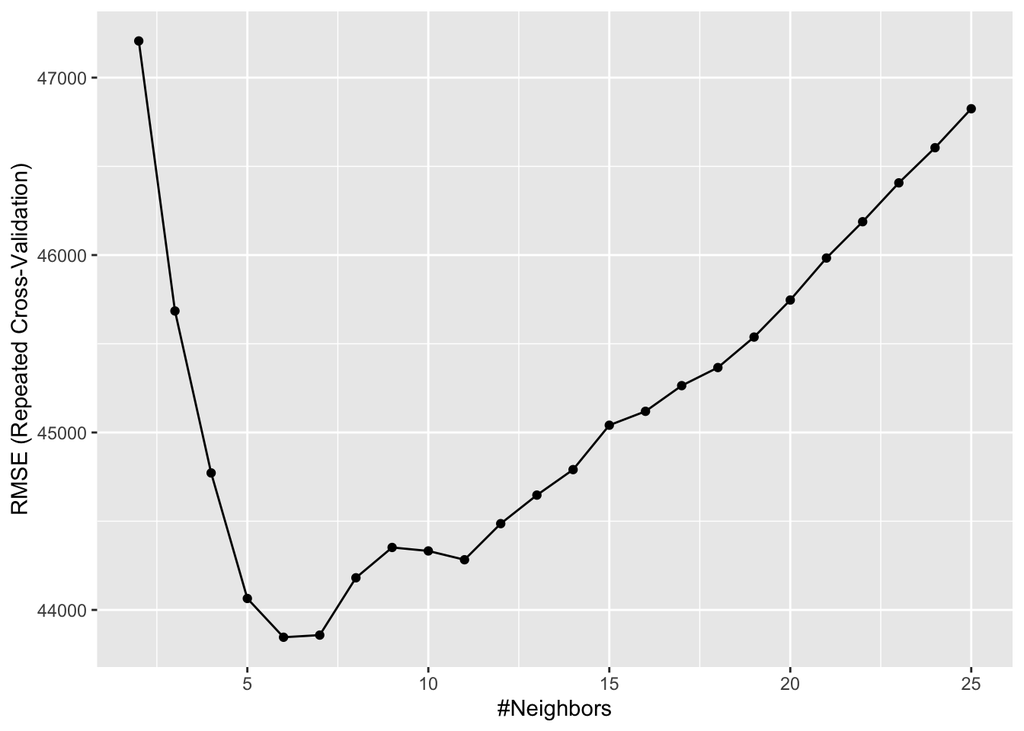

```r
ggplot(knn_fit)
```

# Feature and Target Engineering

```r
library(visdat)
# non-log
nonlog.ames = lm(Sale_Price ~ Year_Built, data=ames)
# log-transform the Y
log.ames = lm(log(Sale_Price) ~ Year_Built, data=ames)

residuals.ames = data.frame(residuals=nonlog.ames$residuals,transformation="none")
residuals.ames = rbind(residuals.ames, data.frame(residuals=log.ames$residuals,transformation="log"))

# Box-cox transformation
bc.ames = MASS::boxcox(nonlog.ames) # run on original model
```

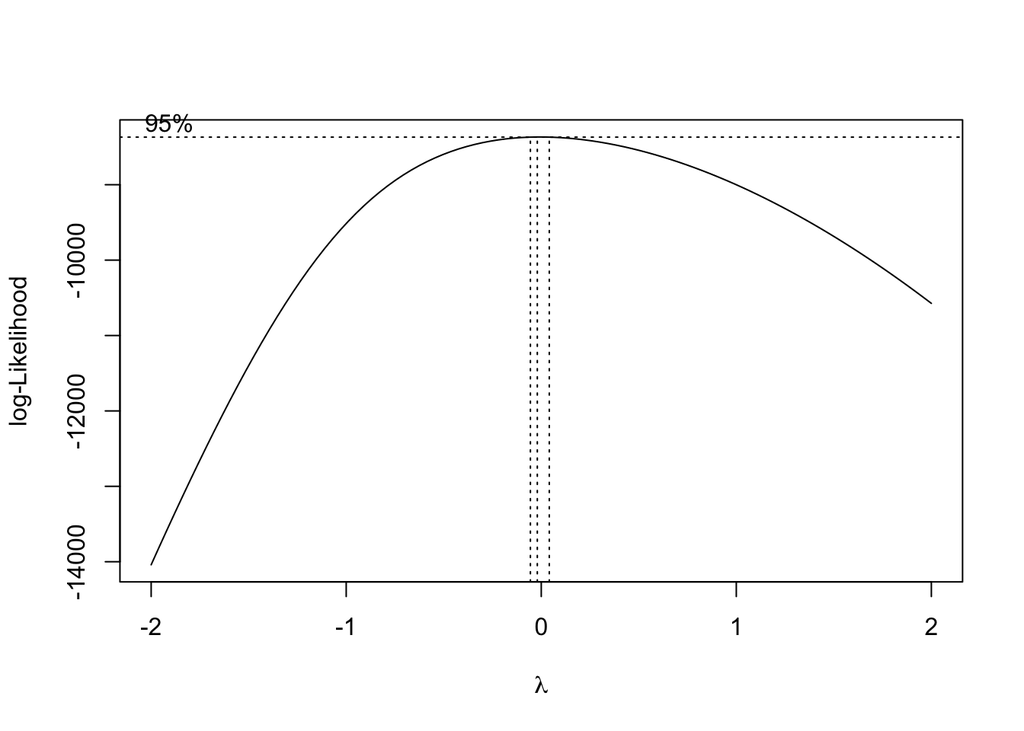

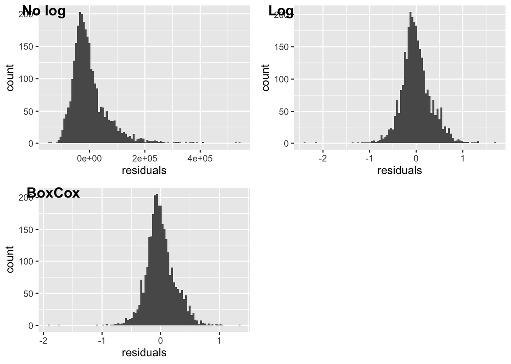

```r
lambda <- bc.ames$x[which.max(bc.ames$y)]
boxcox.ames = lm((Sale_Price^lambda-1)/lambda ~ Year_Built, data=ames)

hist1 = ggplot(data.frame(residuals=nonlog.ames$residuals), aes(residuals)) + geom_histogram(bins=100)

hist2 = ggplot(data.frame(residuals=log.ames$residuals), aes(residuals)) + geom_histogram(bins=100)

hist3 = ggplot(data.frame(residuals=boxcox.ames$residuals), aes(residuals)) + geom_histogram(bins=100)

cowplot::plot_grid(hist1,hist2,hist3,labels=c("No log", "Log", "BoxCox"))
```

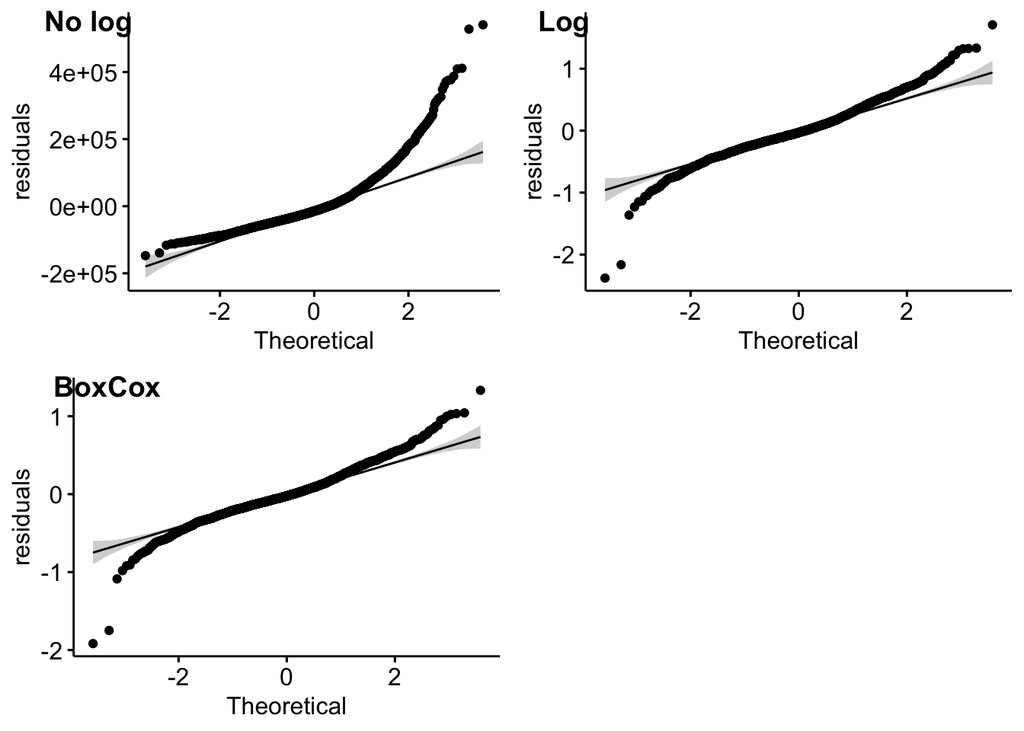

```r
qq1 = ggqqplot(nonlog.ames$residuals) + ylab("residuals")
qq2 = ggqqplot(log.ames$residuals) + ylab("residuals")
qq3 = ggqqplot(boxcox.ames$residuals) + ylab("residuals")

cowplot::plot_grid(qq1,qq2,qq3, labels=c("No log", "Log", "BoxCox"))
```

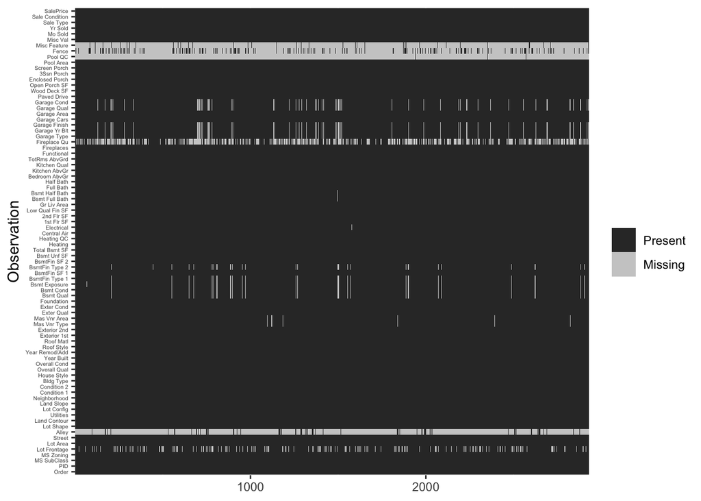

```r
AmesHousing::ames_raw %>%
  is.na() %>%
  reshape2::melt() %>%
  ggplot(aes(Var2, Var1, fill=value)) +
    geom_raster() +
    coord_flip() +
    scale_y_continuous(NULL, expand = c(0, 0)) +
    scale_fill_grey(name = "",
                    labels = c("Present",
                               "Missing")) +
    xlab("Observation") +
    theme(axis.text.y  = element_text(size = 4))
```

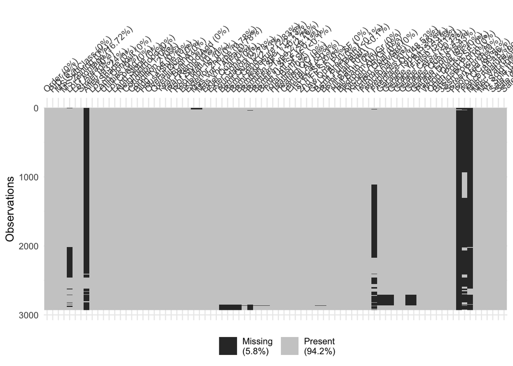

```r
vis_miss(AmesHousing::ames_raw, cluster = TRUE)
```

Digging a little deeper into these variables, we might notice that Garage_Cars and Garage_Area contain the value 0 whenever the other Garage_xx variables have missing values (i.e. a value of NA). This might be because they did not have a way to identify houses with no garages when the data were originally collected, and therefore, all houses with no garage were identified by including nothing. Since this missingness is informative, it would be appropriate to impute NA with a new category level (e.g., “None”) for these garage variables. Circumstances like this tend to only become apparent upon careful descriptive and visual examination of the data!

```r
table(ames_train$Neighborhood) %>% proportions %>% as.data.frame() %>% filter(Freq > .01)
```

```
##                                       Var1       Freq
## 1                               North_Ames 0.14934114
## 2                            College_Creek 0.09712055
## 3                                 Old_Town 0.08003904
## 4                                  Edwards 0.06393363
## 5                                 Somerset 0.05954124
## 6                       Northridge_Heights 0.05661298
## 7                                  Gilbert 0.05417277
## 8                                   Sawyer 0.05270864
## 9                           Northwest_Ames 0.04001952
## 10                             Sawyer_West 0.04587604
## 11                                Mitchell 0.04001952
## 12                               Brookside 0.03611518
## 13                                Crawford 0.03660322
## 14                  Iowa_DOT_and_Rail_Road 0.03660322
## 15                              Timberland 0.02537823
## 16                              Northridge 0.02489019
## 17                             Stone_Brook 0.01952172
## 18 South_and_West_of_Iowa_State_University 0.01561737
## 19                             Clear_Creek 0.01268912
## 20                          Meadow_Village 0.01073694
## 21                               Briardale 0.01122499
```

```r
# just messing around here with clustering instead of "othering"
k.last = kmeans(ames_train$Screen_Porch,centers = 3)
# ranges covered by each cluster
data.frame(x=ames_train$Screen_Porch, k= k.last$cluster) %>% group_by(k) %>% summarize(lower=min(x),upper=max(x),n=length(x))
```

```
## # A tibble: 3 × 4
##       k lower upper     n
##   <int> <int> <int> <int>
## 1     1     0    64  1873
## 2     2   216   490    45
## 3     3    80   210   131
```

```r
# values represented
lapply(split(ames_train$Screen_Porch, k.last$cluster), table)
```

```
## $`1`
##
##    0   40   53   60   64
## 1869    1    1    1    1
##
## $`2`
##
## 216 217 221 224 225 227 233 234 240 252 255 256 260 266 271 273 276 287 288 291
##   4   1   1   5   3   1   1   1   2   1   2   3   1   1   1   1   1   1   4   1
## 312 322 342 348 374 385 396 410 490
##   1   1   1   1   1   1   1   1   1
##
## $`3`
##
##  80  84  88  90  92  94  99 100 104 108 112 115 116 117 120 121 123 126 130 135
##   1   1   1   3   2   1   1   4   1   2   1   2   1   1   5   1   1   3   1   1
## 138 140 141 143 144 145 147 148 150 153 154 155 156 160 161 162 163 164 165 166
##   2   2   1   1  11   1   1   1   1   2   1   3   3   4   3   1   1   1   1   1
## 168 170 171 174 175 176 178 180 182 184 185 189 190 192 195 196 197 198 200 208
##   7   2   1   1   3   2   1   7   2   1   1   4   1   8   2   2   1   1   4   1
## 210
##   3
```

```r
# Ultimately the zeroes dominate, so why break down a small class even further?
table(ames_train$Screen_Porch == 0)
```

```
##
## FALSE  TRUE
##   180  1869
```

```r
#
# FALSE  TRUE
#   180  1869
table(ames_train$Screen_Porch == 0) %>% proportions
```

```
##
##      FALSE       TRUE
## 0.08784773 0.91215227
```

```r
#
#      FALSE       TRUE
# 0.08784773 0.91215227

# Lump levels for two features
lumping <- recipe(Sale_Price ~ ., data = ames_train) %>%
  step_other(Neighborhood, threshold = 0.01,
             other = "other") %>%
  step_other(Screen_Porch, threshold = 0.1,
             other = ">0")


# Apply this blue print --> you will learn about this at
# the end of the chapter
apply_2_training <- prep(lumping, training = ames_train) %>%
  bake(ames_train)

table(apply_2_training$Screen_Porch)
```

```
##
##    0   >0
## 1869  180
```

```r
table(apply_2_training$Neighborhood)
```

```
##
##                              North_Ames                           College_Creek
##                                     306                                     199
##                                Old_Town                                 Edwards
##                                     164                                     131
##                                Somerset                      Northridge_Heights
##                                     122                                     116
##                                 Gilbert                                  Sawyer
##                                     111                                     108
##                          Northwest_Ames                             Sawyer_West
##                                      82                                      94
##                                Mitchell                               Brookside
##                                      82                                      74
##                                Crawford                  Iowa_DOT_and_Rail_Road
##                                      75                                      75
##                              Timberland                              Northridge
##                                      52                                      51
##                             Stone_Brook South_and_West_of_Iowa_State_University
##                                      40                                      32
##                             Clear_Creek                          Meadow_Village
##                                      26                                      22
##                               Briardale                                   other
##                                      23                                      64
```